# **Лабораторна робота №1**

**Тема:**Робота з OpenCV у середовищі Anaconda

**Мета:**quick start для роботи з бібліотекою з відкритим кодом для комп’ютерного зору та обробки зображень OpenCV у середовищі Anaconda із застосуванням Jupyter Notebook засобами мови програмування Python.

## **Завдання для самостійної роботи**

1. Завантажити і встановити збірку Python Anaconda.

[figure not shown]

2. Через інтерфейс командного рядка налаштувати за допомогою **conda** віртуальне середовище з ім’ям *<StudentLastName>_OpenCV*. Етапи роботи підтвердити скріншотами.

[figure not shown]

3. Проінсталювати в створене середовище пакети, необхідні для роботи з OpenCV.

[figure not shown]

4. Створити Notebook-документ *<lab_1_StudentLastName>* за допомогою Jupyter Notebook.

[figure not shown]

5. Відобразити в робочому документі (“зошиті” ipython) виконання пунктів 1-3 індивідуального завдання.
6. Сфотографувати себе на камеру і виконати імпорт і візуалізацію кольорового та напівтонового зображення у робочий документ.
7. Виконати переведення кольорового зображення у напівтонове і записати його на диск.

```
version cv2: 4.12.0
Shape/Dimensions: (149, 199, 3)
Number of pixels: 88953
```

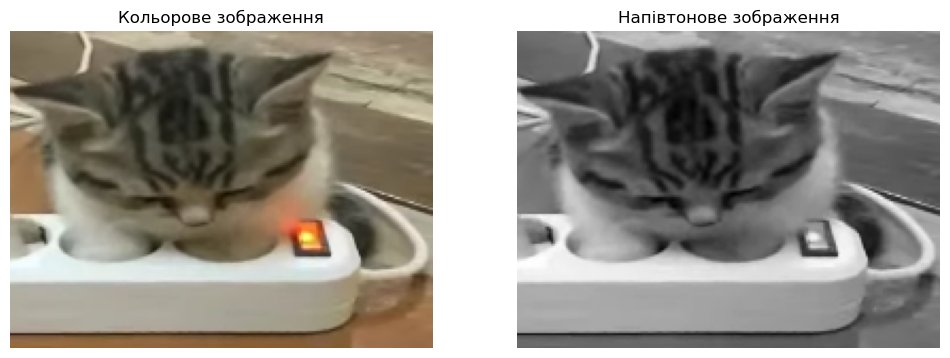

```
True
```

```python
import numpy as np
import cv2 as cv
from matplotlib import pyplot as plt
print(f'version cv2: {cv.__version__}')
image = cv.imread('src/Color.png')
print(f'Shape/Dimensions: {image.shape}')
print(f'Number of pixels: {image.size}')
gray = cv.cvtColor(image_bgr, cv.COLOR_BGR2GRAY)
image_rgb = cv.cvtColor(image_bgr, cv.COLOR_BGR2RGB)

plt.figure(figsize=(12, 6))

plt.subplot(1, 2, 1)
plt.imshow(image_rgb)
plt.title('Кольорове зображення')
plt.axis('off')

plt.subplot(1, 2, 2)
plt.imshow(gray, cmap='gray')
plt.title('Напівтонове зображення')
plt.axis('off')

plt.show()

cv.imwrite('src/Color_gray.jpg', gray)
```

## Контрольні запитання

1. Що таке pip і conda та чим вони відрізняються між собою?

pip — це основний інструмент для встановлення Python-пакетів, який завантажує їх з репозиторію PyPI.

conda — це більш комплексна система керування пакетами та середовищами. Вона дозволяє встановлювати не лише бібліотеки Python, а й бінарні залежності інших мов (C++, R). Ключова відмінність: pip фокусується лише на встановленні бібліотек, тоді як conda керує повним оточенням та сумісністю системних файлів.

2. Як буде виглядати виконання пунктів 1-3 індивідуального завдання за допомогою Virtualenv?

1. Створення ізольованого середовища: `python -m venv myenv`  
 2. Запуск скрипта активації: `myenv\Scripts\activate`  
 3. Інсталяція необхідних бібліотек: `pip install numpy matplotlib opencv-python jupyter`  
 4. Запуск сервера Jupyter: `jupyter notebook`

3. Як виконати візуалізацію зображення (див. п.3) засобами matplotlib?

Оскільки OpenCV зчитує кольори у форматі BGR, а Matplotlib працює з RGB, перед візуалізацією необхідно виконати конвертацію кольорового простору.

Приклад коду:

```
import cv2
import matplotlib.pyplot as plt

Зчитуємо та змінюємо порядок кольорів
image = cv2.imread('src/Color.png')
image_rgb = cv2.cvtColor(image, cv2.COLOR_BGR2RGB)
Виводимо на екран
plt.imshow(image_rgb)
plt.title("Кольорове зображення")
plt.axis("off")
plt.show()
```

4. Як виконати компіляцію вхідного документа Jupyter Notebook із його середовища, не використовуючи інтерфейс командного рядка?

Для цього використовується графічне меню самого ноутбука: натисніть File, потім оберіть Download as. Це дозволяє експортувати поточний документ у зручні формати, такі як HTML або PDF, без використання терміналу.